# 02 — Shadow Comparison and the Migration Readiness Scorecard

Both backends on the same inputs: how often they agreed, who won where they did not, and what the pre-agreed gates say about it.

Same rule as notebook 01 — this notebook displays, it does not compute.

```python
# papermill parameters
MODE = "replay"
CUSTOMER = "demo_patents"
SHADOW_METRIC = "structured"   # structured | item — see section 1
```

```python
%matplotlib inline

from IPython.display import Markdown, display

from amw.config import load_all
from amw.reporting import notebook as nb

cfg = load_all(customer=CUSTOMER)
shadow = nb.load_shadow_result()
phase2 = nb.load_phase2()
display(Markdown(f"**{nb.replay_banner(shadow)}**"))
```

**REPLAY — every number below comes from model calls recorded 2026-08-09T16:07:15+00:00 to 2026-08-10T02:45:25+00:00, not from a run just now.**

## 1. Agreement — and which agreement

"Agreement" is not one number, and the difference is not cosmetic:

- **structured** — only the fields with a defined right answer. Prose is excluded and handled by the triage below.
- **item** — an item agrees only if *every* field matches, with prose scored by a token-overlap proxy at a fixed threshold. This figure moves substantially with that threshold, so it is partly a measurement of the instrument.

|  | subagent | items | n_compared | item_point | item_lo | item_hi | structured_point | structured_lo | structured_hi | prose_threshold | similarity_metric | gate_figure |
| --- | --- | --- | --- | --- | --- | --- | --- | --- | --- | --- | --- | --- |
| 0 | query_rewriter | 70 | 70 | 0.142857 | 0.071429 | 0.228571 | 0.557143 | 0.442857 | 0.671429 | 0.6 | token_jaccard_lexical_proxy | structured |
| 1 | chunk_summarizer | 70 | 70 | 0.128571 | 0.057143 | 0.214286 | 0.957143 | 0.900000 | 1.000000 | 0.6 | token_jaccard_lexical_proxy | structured |
| 2 | feature_extractor | 70 | 70 | 0.200000 | 0.114286 | 0.300000 | 0.971429 | 0.928571 | 1.000000 | 0.6 | token_jaccard_lexical_proxy | structured |

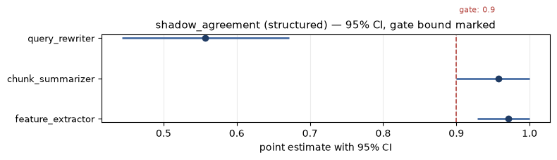

```python
agreement = nb.agreement_frame(shadow, metric=SHADOW_METRIC)
display(agreement)

fig = nb.interval_chart(
    agreement,
    label="subagent",
    point=f"{SHADOW_METRIC}_point",
    lo=f"{SHADOW_METRIC}_lo",
    hi=f"{SHADOW_METRIC}_hi",
    title=f"shadow_agreement ({SHADOW_METRIC}) — 95% CI, gate bound marked",
    bound=cfg.gates.subagent_gates["shadow_agreement"].min,
    bound_label="gate",
)
display(fig)
```

## 2. Latency — not a comparison

Claude ran in `global` (the us-central1 partner quota was exhausted); Gemini and the judge ran in `us-central1`. These percentiles are real measurements of two different regions, so they answer "how fast was each run" and not "which model is faster". The `latency_p95` gate is reported as **not evaluated** for exactly this reason.

```python
latency = nb.latency_frame(shadow)
display(latency[nb.LATENCY_COLUMNS])
display(Markdown(f"> {latency['disclosure'].iloc[0]}"))
```

|  | subagent | side | model | region | n_traces | total_p50_ms | total_p95_ms |
| --- | --- | --- | --- | --- | --- | --- | --- |
| 0 | query_rewriter | baseline | claude-sonnet | global | 70 | 2245.0 | 5967.65 |
| 1 | query_rewriter | candidate | gemini-flash | us-central1 | 70 | 2478.0 | 8306.20 |
| 2 | chunk_summarizer | baseline | claude-sonnet | global | 70 | 4727.0 | 7867.55 |
| 3 | chunk_summarizer | candidate | gemini-flash | us-central1 | 70 | 3407.5 | 6984.35 |
| 4 | feature_extractor | baseline | claude-sonnet | global | 70 | 4488.0 | 6896.65 |
| 5 | feature_extractor | candidate | gemini-flash | us-central1 | 70 | 3252.5 | 4378.15 |

> CROSS-REGION: claude-sonnet ran in global, gemini-flash in us-central1. Latency here compares two regions and is not a like-for-like p95; the gates.yaml basis for latency_p95 asks for same region, same load profile. Regions are read from configuration — traces carry no region field.

## 3. Disagreement triage

Every disagreement, adjudicated from the judge calls phase 2 already recorded — no new judge call is issued here.

`not_adjudicated` is its own verdict with its own reason. An item outside the judged split has no recorded verdict; calling that a tie would manufacture an outcome nobody measured.

```python
for record in shadow.subagents:
    s = record.triage_summary
    print(
        f"{record.subagent}: {s.disagreements} disagreements — "
        f"{s.wins} win / {s.losses} loss / {s.ties} tie / {s.not_adjudicated} not adjudicated"
    )
```

```
query_rewriter: 60 disagreements — 4 win / 11 loss / 9 tie / 36 not adjudicated
chunk_summarizer: 61 disagreements — 2 win / 2 loss / 21 tie / 36 not adjudicated
feature_extractor: 56 disagreements — 5 win / 39 loss / 12 tie / 0 not adjudicated
```

```python
BROWSE_SUBAGENT = "query_rewriter"   # change and re-run to browse another
triage = nb.triage_frame(shadow, subagent=BROWSE_SUBAGENT)
display(triage["verdict"].value_counts().to_frame("rows"))
display(triage[triage["verdict"].isin(["win", "loss"])][nb.TRIAGE_COLUMNS])
```

| verdict | rows |
| --- | --- |
| not_adjudicated | 36 |
| loss | 11 |
| tie | 9 |
| win | 4 |

|  | item_id | verdict | fields | baseline_score | candidate_score | rationale | reason |
| --- | --- | --- | --- | --- | --- | --- | --- |
| 1 | qr-0001 | loss | query, intent | 1.00 | 0.75 | gemini_tuned_v1 lost on [intent_landscape]: Th... |  |
| 2 | qr-0002 | loss | query, intent, filters.date_from, filters.assi... | 0.75 | 0.50 | gemini_tuned_v1 lost on [intent_landscape]: Th... |  |
| 8 | qr-0009 | loss | query | 1.00 | 0.75 | gemini_tuned_v1 lost on [publication_number_ke... |  |
| 13 | qr-0014 | loss | query | 1.00 | 0.75 | gemini_tuned_v1 lost on [publication_number_ke... |  |
| 19 | qr-0021 | win | query, intent | 0.75 | 1.00 | claude_baseline lost on [intent_landscape]: Th... |  |
| 26 | qr-0029 | win | query, filters.jurisdictions | 0.75 | 1.00 | claude_baseline lost on [jurisdiction_only]: T... |  |
| 29 | qr-0034 | loss | query, filters.date_to | 1.00 | 0.80 | gemini_tuned_v1 lost on [date_range_exact]: Th... |  |
| 31 | qr-0036 | loss | intent | 1.00 | 0.75 | gemini_tuned_v1 lost on [intent_landscape]: Th... |  |
| 32 | qr-0038 | loss | query, intent | 1.00 | 0.75 | gemini_tuned_v1 lost on [intent_landscape]: Th... |  |
| 33 | qr-0039 | loss | query | 1.00 | 0.75 | gemini_tuned_v1 lost on [publication_number_ke... |  |
| 35 | qr-0041 | loss | intent | 1.00 | 0.75 | gemini_tuned_v1 lost on [intent_landscape]: Th... |  |
| 39 | qr-0046 | loss | query, intent, filters.date_from, filters.date... | 1.00 | 0.80 | gemini_tuned_v1 lost on [date_range_exact]: Th... |  |
| 43 | qr-0051 | loss | query, intent | 1.00 | 0.75 | gemini_tuned_v1 lost on [inventor_preserved]: ... |  |
| 53 | qr-0062 | win | filters.date_from, filters.assignees, filters.... | 0.50 | 0.75 | claude_baseline lost on [assignee_from_turn_1]... |  |
| 57 | qr-0067 | win | filters.assignees, filters.cpc_codes | 0.50 | 0.75 | claude_baseline lost on [cpc_carried_forward]:... |  |

## 4. The scorecard

Gates checked on their **CI lower bound**, then the verdict rules from `config/gates.yaml`. A gate that was not measured is not a gate that passed: where gates are missing the verdict is **INCOMPLETE**, with the verdict it *would* be shown alongside and labelled as conditional.

```python
from amw.reporting import build_scorecard, render_markdown
from amw.reporting.scorecard import load_shadow

card = build_scorecard(
    cfg,
    phase2,
    shadow=load_shadow(nb.ARTIFACTS / "shadow.json", SHADOW_METRIC),
    shadow_metric=SHADOW_METRIC,
)
display(Markdown(render_markdown(card)))
```

Migration Readiness Scorecard — Demo — Patents RAG

**REPLAY — every number below comes from model calls recorded 2026-08-09T16:07:15+00:00 to 2026-08-10T02:45:59+00:00, not from a run just now.**

Gates are checked against 95% CI bounds, so a passing gate licenses "quality parity within measurement under pre-agreed gates" — never "zero quality drop".

Verdicts

| Subagent | Baseline | Candidate | Gates evaluated | Verdict | Why |
| --- | --- | --- | --- | --- | --- |
| Chunk Summarizer | `claude_baseline` | `gemini_tuned_v1` | 2 of 6 | **INCOMPLETE** (provisional: MIGRATE) | 2 of 6 pre-agreed gates were measured; cost_savings_pct, groundedness_delta_pp, latency_p95, quality_delta_pp were not. A verdict over a subset of the gates is not the verdict that was agreed, so none… |
| Feature Extractor | `claude_baseline` | `gemini_tuned_v1` | 2 of 6 | **INCOMPLETE** (provisional: MIGRATE) | 2 of 6 pre-agreed gates were measured; cost_savings_pct, groundedness_delta_pp, latency_p95, quality_delta_pp were not. A verdict over a subset of the gates is not the verdict that was agreed, so none… |
| Query Rewriter | `claude_baseline` | `gemini_tuned_v1` | 2 of 6 | **HOLD** | blocking gate(s) shadow_agreement failed on the CI bound. Structural failure. Do not migrate this subagent on the current prompt pack. |

Chunk Summarizer

| Gate | Bound (gates.yaml) | Measured (95% CI) | Bound tested | Result |
| --- | --- | --- | --- | --- |
| `quality_delta_pp` | `>= -2.0` | not evaluated — per-item scores were not supplied; phase2.json stores only per-arm aggregates, and a paired bootstrap needs the items | not evaluated | not evaluated |
| `json_schema_validity` | `>= 0.99` | 1.000 [1.000, 1.000] | ci_lower = 1 | PASS |
| `groundedness_delta_pp` | `>= -1.0` | not evaluated — per-item scores were not supplied; phase2.json stores only per-arm aggregates, and a paired bootstrap needs the items | not evaluated | not evaluated |
| `shadow_agreement` | `>= 0.9` | 0.957 [0.900, 1.000] | ci_lower = 0.9 | PASS |
| `cost_savings_pct` | `>= 30.0` | — (prices unverified — run scripts/refresh_pricing.py) | not evaluated | not evaluated |
| `latency_p95` | `<= claude_baseline_p95` | not comparable — region split disclosed | not evaluated | not evaluated |

Evidence

| Evidence | Value |
| --- | --- |
| Claude `json_schema_validity` (`claude_baseline`) | 0.971 [0.929, 1.000] — tool-use JSON; native structured outputs unavailable under this org's policy — not the model's ceiling. |
| Gemini `json_schema_validity` (`gemini_tuned_v1`) | 1.000 [1.000, 1.000] |
| Judge score — Claude | 0.902 [0.830, 0.956] (judged n=28, split=core) |
| Judge score — Gemini | 0.915 [0.871, 0.955] (judged n=28, split=core) |
| Latency p95 | not comparable — region split disclosed |
| Cost per call | — (prices unverified — run scripts/refresh_pricing.py) |
| Monthly run rate | — (prices unverified — run scripts/refresh_pricing.py) |
| Annual run rate | — (prices unverified — run scripts/refresh_pricing.py) |
| Cost savings vs Claude | — (prices unverified — run scripts/refresh_pricing.py) |

**Not evaluated, and why**

- `cost_savings_pct` — not computable — pricing unverified / volumes unconfirmed

- `groundedness_delta_pp` — per-item scores were not supplied; phase2.json stores only per-arm aggregates, and a paired bootstrap needs the items

- `latency_p95` — not comparable — region split disclosed: Claude ran in us-central1, Gemini in us-central1. The claude_baseline_p95 sentinel resolves only from a same-region probe, so this gate is not evaluated — it is not passed.

- `quality_delta_pp` — per-item scores were not supplied; phase2.json stores only per-arm aggregates, and a paired bootstrap needs the items

- shadow_agreement counts **structured fields only** — the fields with a defined right answer. Prose fields are excluded here and adjudicated separately in the disagreement triage; this figure is not a claim that the prose matched.

Feature Extractor

| Gate | Bound (gates.yaml) | Measured (95% CI) | Bound tested | Result |
| --- | --- | --- | --- | --- |
| `quality_delta_pp` | `>= -2.0` | not evaluated — per-item scores were not supplied; phase2.json stores only per-arm aggregates, and a paired bootstrap needs the items | not evaluated | not evaluated |
| `json_schema_validity` | `>= 0.99` | 1.000 [1.000, 1.000] | ci_lower = 1 | PASS |
| `groundedness_delta_pp` | `>= -1.0` | not evaluated — per-item scores were not supplied; phase2.json stores only per-arm aggregates, and a paired bootstrap needs the items | not evaluated | not evaluated |
| `shadow_agreement` | `>= 0.9` | 0.971 [0.929, 1.000] | ci_lower = 0.9286 | PASS |
| `cost_savings_pct` | `>= 30.0` | — (prices unverified — run scripts/refresh_pricing.py) | not evaluated | not evaluated |
| `latency_p95` | `<= claude_baseline_p95` | not comparable — region split disclosed | not evaluated | not evaluated |

Evidence

| Evidence | Value |
| --- | --- |
| Claude `json_schema_validity` (`claude_baseline`) | 0.957 [0.900, 1.000] — tool-use JSON; native structured outputs unavailable under this org's policy — not the model's ceiling. |
| Gemini `json_schema_validity` (`gemini_tuned_v1`) | 1.000 [1.000, 1.000] |
| Judge score — Claude | 0.900 [0.868, 0.929] (judged n=70, split=all) |
| Judge score — Gemini | 0.795 [0.760, 0.828] (judged n=70, split=all) |
| Latency p95 | not comparable — region split disclosed |
| Cost per call | — (prices unverified — run scripts/refresh_pricing.py) |
| Monthly run rate | — (prices unverified — run scripts/refresh_pricing.py) |
| Annual run rate | — (prices unverified — run scripts/refresh_pricing.py) |
| Cost savings vs Claude | — (prices unverified — run scripts/refresh_pricing.py) |

**Not evaluated, and why**

- `cost_savings_pct` — not computable — pricing unverified / volumes unconfirmed

- `groundedness_delta_pp` — per-item scores were not supplied; phase2.json stores only per-arm aggregates, and a paired bootstrap needs the items

- `latency_p95` — not comparable — region split disclosed: Claude ran in us-central1, Gemini in us-central1. The claude_baseline_p95 sentinel resolves only from a same-region probe, so this gate is not evaluated — it is not passed.

- `quality_delta_pp` — per-item scores were not supplied; phase2.json stores only per-arm aggregates, and a paired bootstrap needs the items

- shadow_agreement counts **structured fields only** — the fields with a defined right answer. Prose fields are excluded here and adjudicated separately in the disagreement triage; this figure is not a claim that the prose matched.

Query Rewriter

| Gate | Bound (gates.yaml) | Measured (95% CI) | Bound tested | Result |
| --- | --- | --- | --- | --- |
| `quality_delta_pp` | `>= -2.0` | not evaluated — per-item scores were not supplied; phase2.json stores only per-arm aggregates, and a paired bootstrap needs the items | not evaluated | not evaluated |
| `json_schema_validity` | `>= 0.99` | 1.000 [1.000, 1.000] | ci_lower = 1 | PASS |
| `groundedness_delta_pp` | `>= -1.0` | not evaluated — per-item scores were not supplied; phase2.json stores only per-arm aggregates, and a paired bootstrap needs the items | not evaluated | not evaluated |
| `shadow_agreement` | `>= 0.9` | 0.557 [0.443, 0.671] | ci_lower = 0.4429 | **FAIL** |
| `cost_savings_pct` | `>= 30.0` | — (prices unverified — run scripts/refresh_pricing.py) | not evaluated | not evaluated |
| `latency_p95` | `<= claude_baseline_p95` | not comparable — region split disclosed | not evaluated | not evaluated |

Evidence

| Evidence | Value |
| --- | --- |
| Claude `json_schema_validity` (`claude_baseline`) | 0.814 [0.714, 0.900] — tool-use JSON; native structured outputs unavailable under this org's policy — not the model's ceiling. |
| Gemini `json_schema_validity` (`gemini_tuned_v1`) | 1.000 [1.000, 1.000] |
| Judge score — Claude | 0.911 [0.839, 0.964] (judged n=28, split=core) |
| Judge score — Gemini | 0.852 [0.796, 0.905] (judged n=28, split=core) |
| Latency p95 | not comparable — region split disclosed |
| Cost per call | — (prices unverified — run scripts/refresh_pricing.py) |
| Monthly run rate | — (prices unverified — run scripts/refresh_pricing.py) |
| Annual run rate | — (prices unverified — run scripts/refresh_pricing.py) |
| Cost savings vs Claude | — (prices unverified — run scripts/refresh_pricing.py) |

**Not evaluated, and why**

- `cost_savings_pct` — not computable — pricing unverified / volumes unconfirmed

- `groundedness_delta_pp` — per-item scores were not supplied; phase2.json stores only per-arm aggregates, and a paired bootstrap needs the items

- `latency_p95` — not comparable — region split disclosed: Claude ran in us-central1, Gemini in us-central1. The claude_baseline_p95 sentinel resolves only from a same-region probe, so this gate is not evaluated — it is not passed.

- `quality_delta_pp` — per-item scores were not supplied; phase2.json stores only per-arm aggregates, and a paired bootstrap needs the items

- shadow_agreement counts **structured fields only** — the fields with a defined right answer. Prose fields are excluded here and adjudicated separately in the disagreement triage; this figure is not a claim that the prose matched.

Economics

**not computable — pricing unverified / volumes unconfirmed.** No dollar figure is produced — not a zero, not a placeholder. Both gates below are independent and each has to be cleared by a human.

| Gate | Why it is closed | Clears when |
| --- | --- | --- |
| pricing | config/pricing.yaml has 13 rate(s) still reading VERIFY and verified_on is null | a human runs scripts/refresh_pricing.py |
| volumes | the customer profile's volume block is illustrative (volumes_confirmed: false) | the customer states their call volumes — economics.confirm_volumes() or `cli.py scorecard --volume` |

Volume basis: volumes: illustrative — 3 evaluated subagent(s), x0.5/x1/x2 sensitivity band and cached/uncached rows ready to run the moment both gates clear.

Footer

Verdicts apply to each subagent's measured behavior class (Level 1 single-call transforms, measured in full here); tool-selection and multi-step trajectory behaviors are evaluated with their own instruments in the follow-on and receive no verdict today.

| Field | Value |
| --- | --- |
| Customer | Demo — Patents RAG (`demo_patents`) |
| Provenance | synthetic, generator `t06.1`, dataset seed `20260812` |
| Bootstrap | 95% CI, seed `20260812` |
| Judge | Gemini 2.5 Pro, prompt `v1`, k=2 repeats |
| Mode | `replay` |
| Run date | no live run — assembled from recordings |
| Recording window | 2026-08-09T16:07:15+00:00 to 2026-08-10T02:45:59+00:00 |
| Region(s) | Claude `us-central1`, Gemini + judge `us-central1` (source: $CLAUDE_REGION / $REGION, falling back to the customer profile) |
| Prices verified on | UNVERIFIED — 13 rates still read `VERIFY` |
| Pricing sources | https://cloud.google.com/vertex-ai/generative-ai/pricing, https://cloud.google.com/vertex-ai/generative-ai/pricing#claude-models, https://claude.com/pricing |
| Volumes | volumes: illustrative |
| Gates | version 1, hash `92f9d018432f` |

**Run notes**

- judged on the FULL corpus, not the registered core split: feature_extractor. Every other subagent is judged on core only, so judged n differs across subagents — see each arm's judge.split and judge.items_scored before comparing judge scores.

### Reproducing this outside the notebook

```
python cli.py shadow --mode replay
python cli.py scorecard --mode replay \
    --shadow artifacts/results/shadow.json \
    --shadow-metric structured \
    --out artifacts/reports/scorecard.md
```

The scorecard above is built with `samples=None`, so the two paired-delta gates (`quality_delta_pp`, `groundedness_delta_pp`) report as not evaluated here. The CLI re-derives them by replaying the recorded calls; that takes about a minute, which is why it is a command and not a cell.